# 1 Activity monitoring data

## 1.1 Introduction

It is now possible to collect a large amount of data about personal movement using activity monitoring devices such as a Fitbit, Nike Fuelband, or Jawbone Up. These type of devices are part of the “quantified self” movement – a group of enthusiasts who take measurements about themselves regularly to improve their health, to find patterns in their behavior, or because they are tech geeks. But these data remain under-utilized both because the raw data are hard to obtain and there is a lack of statistical methods and software for processing and interpreting the data.

This assignment makes use of data from a personal activity monitoring device. This device collects data at 5 minute intervals through out the day. The data consists of two months of data from an anonymous individual collected during the months of October and November, 2012 and include the number of steps taken in 5 minute intervals each day.

### 1.1.1 Total number of steps taken per day

The median number of steps taken each day was **10,395**, whilst the mean was **9,354**, when missing values were not considered. A histogram displays the distribution of total steps in a day below .Note that a considerable number of observations had missing values, denoted in the 0 bar.

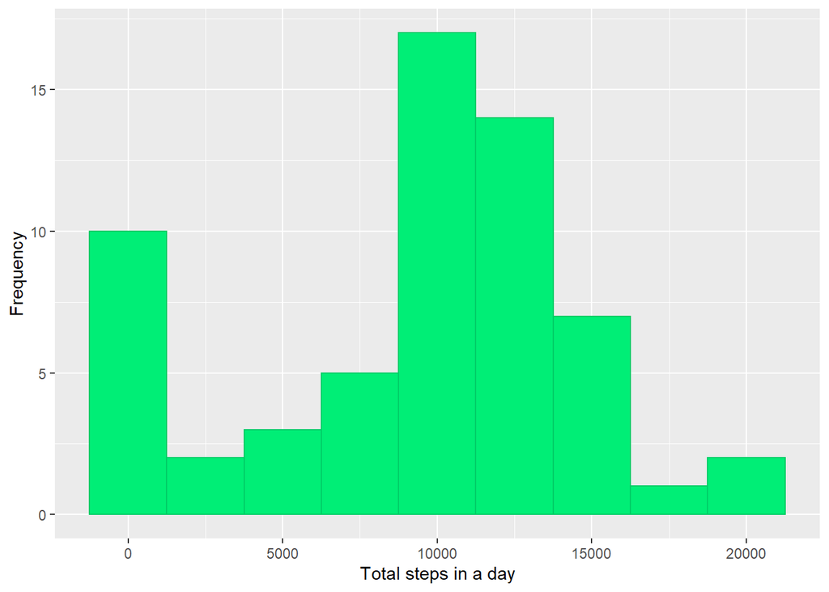

Figure 1.1: Histogram of total number of steps taken per day

### 1.1.2 Daily activity pattern

The maximum number of steps on average was observed on the **835th** interval.

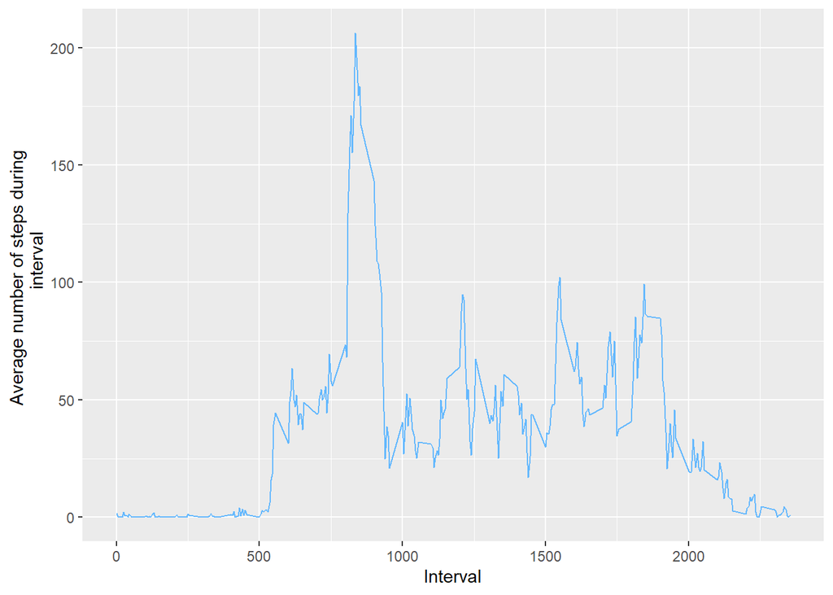

Figure 1.2: Time series plot of average number of steps versus interval

### 1.1.3 Missing values

The dataset contained many missing values. Out of **17,568** observations, only **15,264** were complete with the remaining **2,304** missing data on the number of steps.When missing values were imputed, the median number of steps taken each day was **10,766**, whilst the mean was **10,766**, both values higher than estimated when excluding missing data.

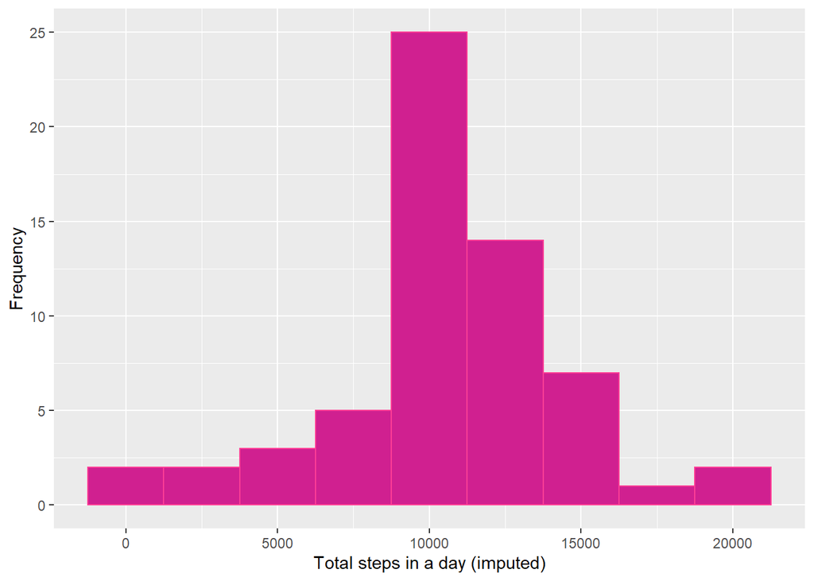

Figure 1.3: Histogram of total number of steps taken per day with imputed data

### 1.1.4 Differences between weekdays and weekends

The plots below display the average number of steps at different intervals during weekdays and weekends.

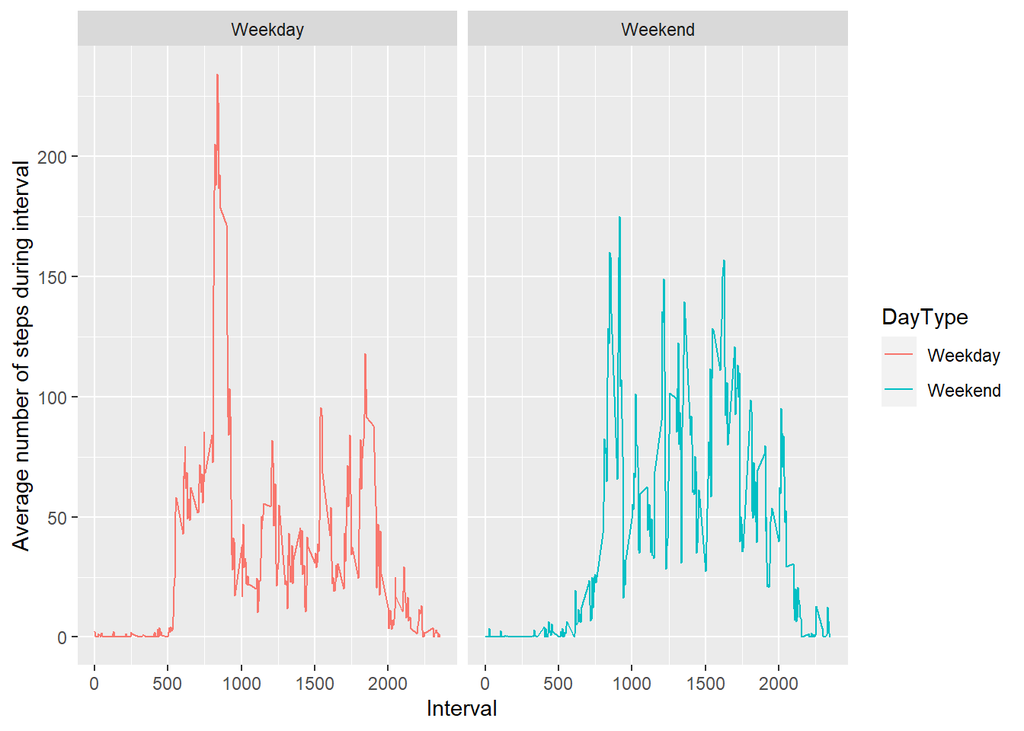

Figure 1.4: Time series plot of interval versus average number of steps by type of day